# PML writeup

aureliengmn

Here is the R code I have used to build my predictive model.

First I needed to import the dataset, but some predictors were imported in factor due to lots of missing values. I had to transform them to numeric.

```r
setwd("C:/Users/Aurelien/Documents/GitHub/PML")

# Import
data <- read.csv("pml-training.csv", sep=",", na.strings = "NA")
nb_pred <- dim(data)[2]-1
for (i in 7:nb_pred){
  data[,i] <- as.numeric(data[,i])
}
```

Before any visualization, I have divided my dataset on a training and a testing set (70% / 30%), using caret package. Then I’ve checked that predictors had some variability and I have dropped the ones that had not enough variation.

```r
require(caret)
inTrain <- createDataPartition(y=data$classe, p=0.7, list=FALSE)

training <- data[inTrain, ]
testing <- data[-inTrain, ]

#preview
head(nearZeroVar(training[,c(15:dim(training)[2])], saveMetrics = TRUE))
```

```
##                       freqRatio percentUnique zeroVar   nzv
## skewness_roll_belt   2243.16667    1.98005387   FALSE  TRUE
## skewness_roll_belt.1  708.36842    1.72526753   FALSE  TRUE
## skewness_yaw_belt      48.41367    0.01455922   FALSE  TRUE
## max_roll_belt           1.12500    1.08466186   FALSE FALSE
## max_picth_belt          1.34000    0.14559220   FALSE FALSE
## max_yaw_belt          672.95000    0.42221737   FALSE  TRUE
```

```r
training <- training[,-nearZeroVar(training)]
```

I plotted the distribution of each feature/classe in one big .PDF to understand the data set. Here is one example.

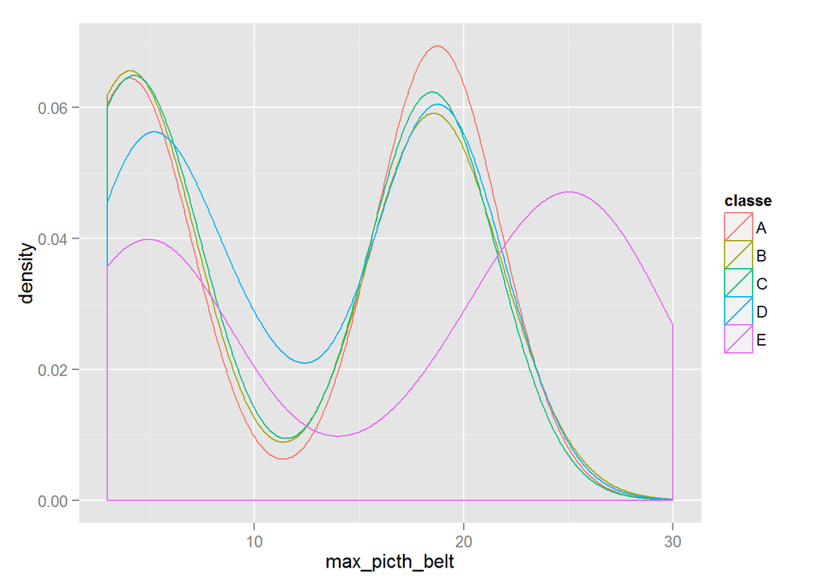

```r
#pdf("var.pdf")
#for (i in 1:dim(training)[2]){
#  if (is.numeric(training[,i])==T)

#    print(qplot(training[!is.na(training[,i]),i], colour=classe, data=training[!is.na(training[,i]),],            geom="density", xlab =colnames(training[i])))
#}
#dev.off()

# example
i<-12
print(qplot(training[!is.na(training[,i]),i], colour=classe, data=training[!is.na(training[,i]),],
            geom="density", xlab =colnames(training[i])))
```

I had still to much predicors with missing values, that were not excluded with the nearZeroVar fonction. I used the randomForest package to assign predictors means to missing values and I dropped predictors wich had nearZeroVar with this implementation. In the end i use only 36 features to estimate the modele.

```r
require(randomForest)
train_na <- na.roughfix(training)

train_final <- train_na[,-nearZeroVar(train_na)]
```

I choose to use a RandomForest classification to solve the problem because it can deal easely with extreme values and predictors don’t need to be standardized. I made different models and i found that didn’t need to run 500 tree (the default option) which was time consuming. I’ve choose instead to do some repeated cross validations to select the best forest with 100 trees.

```r
library(doParallel)
cl <- makeCluster(detectCores())
registerDoParallel(cl)

tc <- trainControl("repeatedcv", number=10, repeats=5, classProbs=TRUE, savePred=T)

RF <- train(classe~., data=train_final, method="rf", ntree=100, tuneGrid=data.frame(.mtry = 3), trControl=tc,
            allowParallel=T, importance = TRUE)

stopCluster(cl)
RF$finalModel
```

```
##
## Call:
##  randomForest(x = x, y = y, ntree = 100, mtry = param$mtry, importance = TRUE,      allowParallel = ..2)
##                Type of random forest: classification
##                      Number of trees: 100
## No. of variables tried at each split: 3
##
##         OOB estimate of  error rate: 0.1%
## Confusion matrix:
##      A    B    C    D    E  class.error
## A 3906    0    0    0    0 0.0000000000
## B    0 2656    2    0    0 0.0007524454
## C    0    4 2390    2    0 0.0025041736
## D    0    0    2 2249    1 0.0013321492
## E    0    0    0    3 2522 0.0011881188
```

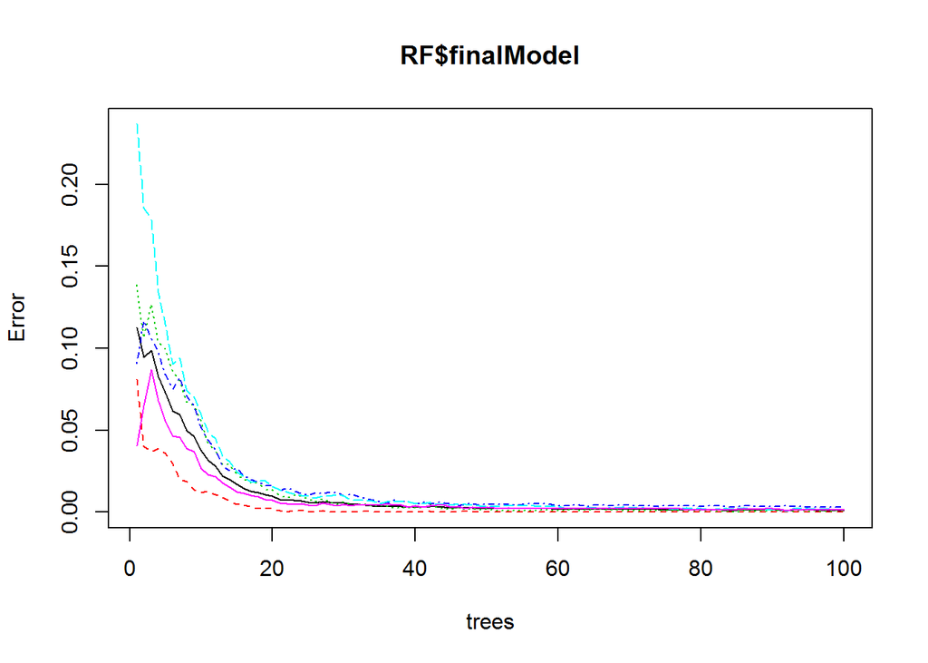

```r
plot(RF$finalModel)
```

We can see here that the error was almost at its minimum at 30 trees.

On the model summary, we can see that the Out Of Bag Error is very low, around 0.1 on the training dataset.

I had printed features that had importance in models construction, and I applied the model on the testing dataset to print the confusion matrix on unseen data. Only few observations are on the wrong “classe”.

```r
head(varImp(RF$finalModel, scale=TRUE))
```

```
##                           A         B         C         D         E
## X                 11.665490 11.857685 13.071213 12.460037 13.314310
## user_namecarlitos  3.348235  5.477602  4.134306  3.630961  4.748600
## user_namecharles   3.800316  3.327576  3.734876  4.134278  4.581610
## user_nameeurico    3.956862  4.054688  4.599708  5.583929  5.410231
## user_namejeremy    2.869870  3.810178  3.711044  3.907148  3.274868
## user_namepedro     2.750786  2.920028  3.695575  2.008968  2.623258
```

```r
testing <- na.roughfix(testing)
pred <- predict(RF,testing)

confusionMatrix(pred, testing$classe)
```

```
## Confusion Matrix and Statistics
##
##           Reference
## Prediction    A    B    C    D    E
##          A 1674    2    0    0    0
##          B    0 1137    0    0    0
##          C    0    0 1026    2    0
##          D    0    0    0  962    1
##          E    0    0    0    0 1081
##
## Overall Statistics
##
##                Accuracy : 0.9992
##                  95% CI : (0.998, 0.9997)
##     No Information Rate : 0.2845
##     P-Value [Acc > NIR] : < 2.2e-16
##
##                   Kappa : 0.9989
##  Mcnemar's Test P-Value : NA
##
## Statistics by Class:
##
##                      Class: A Class: B Class: C Class: D Class: E
## Sensitivity            1.0000   0.9982   1.0000   0.9979   0.9991
## Specificity            0.9995   1.0000   0.9996   0.9998   1.0000
## Pos Pred Value         0.9988   1.0000   0.9981   0.9990   1.0000
## Neg Pred Value         1.0000   0.9996   1.0000   0.9996   0.9998
## Prevalence             0.2845   0.1935   0.1743   0.1638   0.1839
## Detection Rate         0.2845   0.1932   0.1743   0.1635   0.1837
## Detection Prevalence   0.2848   0.1932   0.1747   0.1636   0.1837
## Balanced Accuracy      0.9998   0.9991   0.9998   0.9989   0.9995
```

Here, the confusion matrix shows some very good performance on the model, only 5 observations are on the wrong "classe", the accuracy is almost 1.

I have applied this model to predict the “classe” variable on the 20 observations dataset for the submission and it scored 20 on 20.